# Assignment5

## **Load Libraries**

```r
library(readr)
library(cluster)
library(stats)
library(dplyr)
library(caret)
library(tidyverse)
library(factoextra)
```

## **Import Data**

```r
Cereals <- read_csv("Cereals.csv")
```

*Data sourced from Canvas.*

## **Turn Names Into Row Names**

```r
head(Cereals)
```

```
## # A tibble: 6 × 16
##   name       mfr   type  calories protein   fat sodium fiber carbo sugars potass
##   <chr>      <chr> <chr>    <dbl>   <dbl> <dbl>  <dbl> <dbl> <dbl>  <dbl>  <dbl>
## 1 100%_Bran  N     C           70       4     1    130  10     5        6    280
## 2 100%_Natu… Q     C          120       3     5     15   2     8        8    135
## 3 All-Bran   K     C           70       4     1    260   9     7        5    320
## 4 All-Bran_… K     C           50       4     0    140  14     8        0    330
## 5 Almond_De… R     C          110       2     2    200   1    14        8     NA
## 6 Apple_Cin… G     C          110       2     2    180   1.5  10.5     10     70
## # ℹ 5 more variables: vitamins <dbl>, shelf <dbl>, weight <dbl>, cups <dbl>,
## #   rating <dbl>
```

```r
Cereals_df <- as.data.frame(Cereals)
Cereal_Names <- Cereals_df$name
rownames(Cereals_df) <- Cereal_Names
Cereals_df <- Cereals_df[,-1]
head(Cereals_df)
```

```
##                           mfr type calories protein fat sodium fiber carbo
## 100%_Bran                   N    C       70       4   1    130  10.0   5.0
## 100%_Natural_Bran           Q    C      120       3   5     15   2.0   8.0
## All-Bran                    K    C       70       4   1    260   9.0   7.0
## All-Bran_with_Extra_Fiber   K    C       50       4   0    140  14.0   8.0
## Almond_Delight              R    C      110       2   2    200   1.0  14.0
## Apple_Cinnamon_Cheerios     G    C      110       2   2    180   1.5  10.5
##                           sugars potass vitamins shelf weight cups   rating
## 100%_Bran                      6    280       25     3      1 0.33 68.40297
## 100%_Natural_Bran              8    135        0     3      1 1.00 33.98368
## All-Bran                       5    320       25     3      1 0.33 59.42551
## All-Bran_with_Extra_Fiber      0    330       25     3      1 0.50 93.70491
## Almond_Delight                 8     NA       25     3      1 0.75 34.38484
## Apple_Cinnamon_Cheerios       10     70       25     1      1 0.75 29.50954
```

## **Remove Missing Values**

```r
colMeans(is.na(Cereals_df))
```

```
##        mfr       type   calories    protein        fat     sodium      fiber
## 0.00000000 0.00000000 0.00000000 0.00000000 0.00000000 0.00000000 0.00000000
##      carbo     sugars     potass   vitamins      shelf     weight       cups
## 0.01298701 0.01298701 0.02597403 0.00000000 0.00000000 0.00000000 0.00000000
##     rating
## 0.00000000
```

```r
sum(!complete.cases(Cereals_df))
```

```
## [1] 3
```

```r
Cereals_Clean <- Cereals_df[complete.cases(Cereals_df), ]
colMeans(is.na(Cereals_Clean))
```

```
##      mfr     type calories  protein      fat   sodium    fiber    carbo
##        0        0        0        0        0        0        0        0
##   sugars   potass vitamins    shelf   weight     cups   rating
##        0        0        0        0        0        0        0
```

## **Create Dummy Variables**

```r
head(Cereals_Clean)
```

```
##                           mfr type calories protein fat sodium fiber carbo
## 100%_Bran                   N    C       70       4   1    130  10.0   5.0
## 100%_Natural_Bran           Q    C      120       3   5     15   2.0   8.0
## All-Bran                    K    C       70       4   1    260   9.0   7.0
## All-Bran_with_Extra_Fiber   K    C       50       4   0    140  14.0   8.0
## Apple_Cinnamon_Cheerios     G    C      110       2   2    180   1.5  10.5
## Apple_Jacks                 K    C      110       2   0    125   1.0  11.0
##                           sugars potass vitamins shelf weight cups   rating
## 100%_Bran                      6    280       25     3      1 0.33 68.40297
## 100%_Natural_Bran              8    135        0     3      1 1.00 33.98368
## All-Bran                       5    320       25     3      1 0.33 59.42551
## All-Bran_with_Extra_Fiber      0    330       25     3      1 0.50 93.70491
## Apple_Cinnamon_Cheerios       10     70       25     1      1 0.75 29.50954
## Apple_Jacks                   14     30       25     2      1 1.00 33.17409
```

```r
Dummies <- dummyVars(~ mfr + type, data = Cereals_Clean)
Dummy_df <- as.data.frame(predict(Dummies, newdata = Cereals_Clean))
Cereals_Num <- Cereals_Clean[,-c(1,2)]
Cereals_Num <- cbind(Dummy_df,Cereals_Num)
head(Cereals_Num)
```

```
##                           mfrA mfrG mfrK mfrN mfrP mfrQ mfrR typeC typeH
## 100%_Bran                    0    0    0    1    0    0    0     1     0
## 100%_Natural_Bran            0    0    0    0    0    1    0     1     0
## All-Bran                     0    0    1    0    0    0    0     1     0
## All-Bran_with_Extra_Fiber    0    0    1    0    0    0    0     1     0
## Apple_Cinnamon_Cheerios      0    1    0    0    0    0    0     1     0
## Apple_Jacks                  0    0    1    0    0    0    0     1     0
##                           calories protein fat sodium fiber carbo sugars potass
## 100%_Bran                       70       4   1    130  10.0   5.0      6    280
## 100%_Natural_Bran              120       3   5     15   2.0   8.0      8    135
## All-Bran                        70       4   1    260   9.0   7.0      5    320
## All-Bran_with_Extra_Fiber       50       4   0    140  14.0   8.0      0    330
## Apple_Cinnamon_Cheerios        110       2   2    180   1.5  10.5     10     70
## Apple_Jacks                    110       2   0    125   1.0  11.0     14     30
##                           vitamins shelf weight cups   rating
## 100%_Bran                       25     3      1 0.33 68.40297
## 100%_Natural_Bran                0     3      1 1.00 33.98368
## All-Bran                        25     3      1 0.33 59.42551
## All-Bran_with_Extra_Fiber       25     3      1 0.50 93.70491
## Apple_Cinnamon_Cheerios         25     1      1 0.75 29.50954
## Apple_Jacks                     25     2      1 1.00 33.17409
```

## **Normalize Data**

```r
Norm_Model <- preProcess(Cereals_Num, method = c("center", "scale"))
Cereals_Norm <- predict(Norm_Model,Cereals_Num)
head(Cereals_Norm)
```

```
##                                 mfrA       mfrG       mfrK       mfrN
## 100%_Bran                 -0.1162476 -0.6460338 -0.6669978  3.6896495
## 100%_Natural_Bran         -0.1162476 -0.6460338 -0.6669978 -0.2673659
## All-Bran                  -0.1162476 -0.6460338  1.4789951 -0.2673659
## All-Bran_with_Extra_Fiber -0.1162476 -0.6460338  1.4789951 -0.2673659
## Apple_Cinnamon_Cheerios   -0.1162476  1.5269890 -0.6669978 -0.2673659
## Apple_Jacks               -0.1162476 -0.6460338  1.4789951 -0.2673659
##                                 mfrP       mfrQ       mfrR     typeC      typeH
## 100%_Bran                 -0.3695814 -0.3210386 -0.3210386 0.1162476 -0.1162476
## 100%_Natural_Bran         -0.3695814  3.0727976 -0.3210386 0.1162476 -0.1162476
## All-Bran                  -0.3695814 -0.3210386 -0.3210386 0.1162476 -0.1162476
## All-Bran_with_Extra_Fiber -0.3695814 -0.3210386 -0.3210386 0.1162476 -0.1162476
## Apple_Cinnamon_Cheerios   -0.3695814 -0.3210386 -0.3210386 0.1162476 -0.1162476
## Apple_Jacks               -0.3695814 -0.3210386 -0.3210386 0.1162476 -0.1162476
##                             calories    protein        fat     sodium
## 100%_Bran                 -1.8659155  1.3817478  0.0000000 -0.3910227
## 100%_Natural_Bran          0.6537514  0.4522084  3.9728810 -1.7804186
## All-Bran                  -1.8659155  1.3817478  0.0000000  1.1795987
## All-Bran_with_Extra_Fiber -2.8737823  1.3817478 -0.9932203 -0.2702057
## Apple_Cinnamon_Cheerios    0.1498180 -0.4773310  0.9932203  0.2130625
## Apple_Jacks                0.1498180 -0.4773310 -0.9932203 -0.4514312
##                                 fiber      carbo     sugars     potass
## 100%_Bran                  3.22866747 -2.5001396 -0.2542051  2.5605229
## 100%_Natural_Bran         -0.07249167 -1.7292632  0.2046041  0.5147738
## All-Bran                   2.81602258 -1.9862220 -0.4836096  3.1248675
## All-Bran_with_Extra_Fiber  4.87924705 -1.7292632 -1.6306324  3.2659536
## Apple_Cinnamon_Cheerios   -0.27881412 -1.0868662  0.6634132 -0.4022862
## Apple_Jacks               -0.48513656 -0.9583868  1.5810314 -0.9666308
##                             vitamins      shelf     weight       cups
## 100%_Bran                 -0.1818422  0.9419715 -0.2008324 -2.0856582
## 100%_Natural_Bran         -1.3032024  0.9419715 -0.2008324  0.7567534
## All-Bran                  -0.1818422  0.9419715 -0.2008324 -2.0856582
## All-Bran_with_Extra_Fiber -0.1818422  0.9419715 -0.2008324 -1.3644493
## Apple_Cinnamon_Cheerios   -0.1818422 -1.4616799 -0.2008324 -0.3038480
## Apple_Jacks               -0.1818422 -0.2598542 -0.2008324  0.7567534
##                               rating
## 100%_Bran                  1.8549038
## 100%_Natural_Bran         -0.5977113
## All-Bran                   1.2151965
## All-Bran_with_Extra_Fiber  3.6578436
## Apple_Cinnamon_Cheerios   -0.9165248
## Apple_Jacks               -0.6553998
```

# **Question 1:**

## **Agnes Linkage Methods**

```r
hc_single <- agnes(Cereals_Norm, method = "single")
hc_complete <- agnes(Cereals_Norm, method = "complete")
hc_average <- agnes(Cereals_Norm, method = "average")
hc_ward <- agnes(Cereals_Norm, method = "ward")

Methods <- data.frame(Single = hc_single$ac, Complete = hc_complete$ac,
                      Average = hc_average$ac, Ward = hc_ward$ac)
Methods
```

```
##      Single  Complete   Average      Ward
## 1 0.8543243 0.8618592 0.8518632 0.8853988
```

```r
max(Methods)
```

```
## [1] 0.8853988
```

```r
names(which.max(Methods))
```

```
## [1] "Ward"
```

The best method is “Ward” with the ac value of 0.8853988.

## **Agnes Dendrogram**

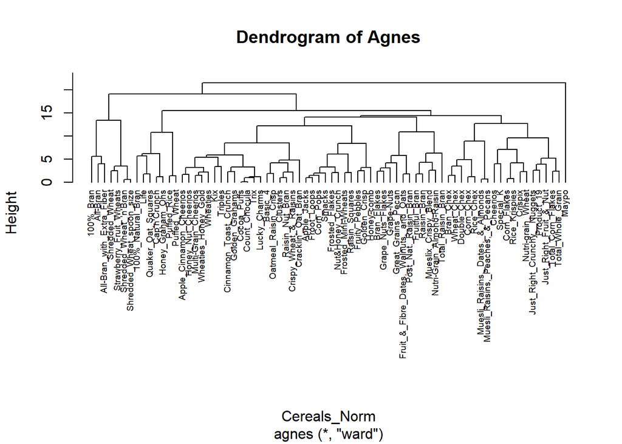

```r
pltree(hc_ward, cex = 0.6, hang = -1, main = "Dendrogram of Agnes")
```

# **Question 2:**

## **Choosing Number of Clusters**

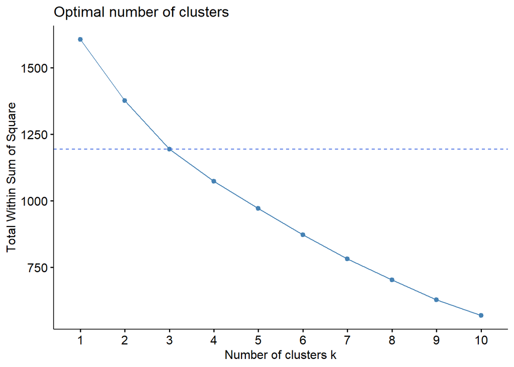

```r
fviz_nbclust(Cereals_Norm, hcut, method = "wss") +
  geom_hline(yintercept = 1194, linetype = 2, color = "royalblue", size = 0.5)
```

After looking at the Dendrogram’s height differences and using the Elbow Method (WSS), I chose 3 clusters.

## **3 Clusters Dendrogram**

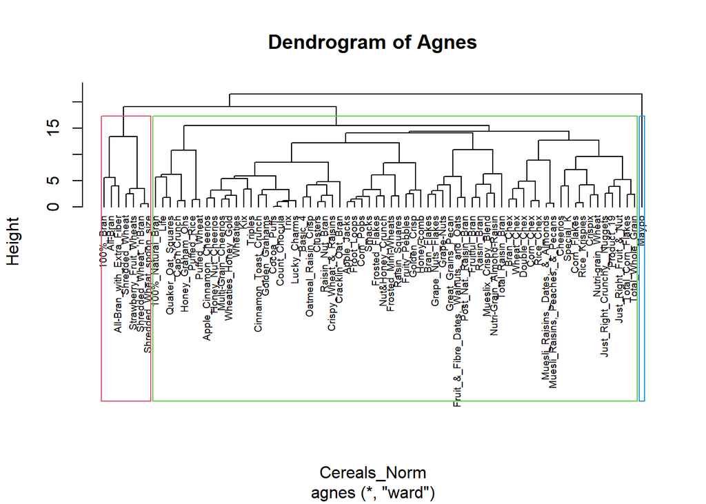

```r
pltree(hc_ward, cex = 0.6, hang = -1, main = "Dendrogram of Agnes")
rect.hclust(as.hclust(hc_ward), k = 3, border = 2:5)
```

# **Question 3:**

## **Stability Check**

```r
set.seed(124) # seed(123) is unbalanced
Index_Partition <- createDataPartition(1:nrow(Cereals_Norm), p = 0.7, list = F)
PartA <- Cereals_Norm[Index_Partition,]
PartB <- Cereals_Norm[-Index_Partition,]

Clusters_Ward <- cutree(as.hclust(hc_ward), k = 3)
Clusters_B <- Clusters_Ward[-Index_Partition]

hc_A <- agnes(PartA, method = "ward")
Clusters_A <- cutree(as.hclust(hc_A), k = 3)


Centroids <- PartA %>%
  mutate(Cluster = Clusters_A) %>%
  group_by(Cluster) %>%
  summarise(across(everything(), mean))
Centroids
```

```
## # A tibble: 3 × 23
##   Cluster   mfrA    mfrG    mfrK   mfrN   mfrP   mfrQ    mfrR typeC  typeH
##     <int>  <dbl>   <dbl>   <dbl>  <dbl>  <dbl>  <dbl>   <dbl> <dbl>  <dbl>
## 1       1 -0.116 -0.646  -0.399   2.21  -0.370  0.527 -0.321  0.116 -0.116
## 2       2 -0.116  0.0990 -0.0539 -0.267  0.238 -0.127  0.0668 0.116 -0.116
## 3       3 -0.116  0.144   0.699  -0.267 -0.370 -0.321 -0.321  0.116 -0.116
## # ℹ 13 more variables: calories <dbl>, protein <dbl>, fat <dbl>, sodium <dbl>,
## #   fiber <dbl>, carbo <dbl>, sugars <dbl>, potass <dbl>, vitamins <dbl>,
## #   shelf <dbl>, weight <dbl>, cups <dbl>, rating <dbl>
```

```r
Centroid_1 <- Centroids[1,-1]
Centroid_2 <- Centroids[2,-1]
Centroid_3 <- Centroids[3,-1]

Cent_Dist_1 <- sqrt(rowSums((PartB - as.list(Centroid_1))^2))
Cent_Dist_2 <- sqrt(rowSums((PartB - as.list(Centroid_2))^2))
Cent_Dist_3 <- sqrt(rowSums((PartB - as.list(Centroid_3))^2))

Centroid_Distances <- data.frame(
  Dist1 = Cent_Dist_1,
  Dist2 = Cent_Dist_2,
  Dist3 = Cent_Dist_3
)

Centroid_Distances$Assigned_Cluster <- max.col(-1*Centroid_Distances)
Centroid_Distances$HC_Cluster <- Clusters_B
Centroid_Distances
```

```
##                          Dist1     Dist2     Dist3 Assigned_Cluster HC_Cluster
## 100%_Natural_Bran     7.583323  6.000402  7.235313                2          2
## All-Bran              6.283883  6.609595  6.742824                1          1
## Corn_Chex             7.163454  4.896852  5.881778                2          2
## Corn_Flakes           6.163227  4.125952  4.718241                2          2
## Count_Chocula         6.900371  2.731939  4.596292                2          2
## Double_Chex           5.960976  3.989591  4.992305                2          2
## Frosted_Mini-Wheats   4.178974  3.537682  4.520064                2          2
## Grape-Nuts            5.799184  4.524942  5.357196                2          2
## Great_Grains_Pecan    6.394515  4.491039  5.588007                2          2
## Honey_Graham_Ohs      7.263272  4.106260  5.542401                2          2
## Kix                   7.045274  4.367233  4.996872                2          2
## Maypo                15.556624 15.346512 15.663378                2          3
## Multi-Grain_Cheerios  5.624327  2.613201  4.295482                2          2
## Oatmeal_Raisin_Crisp  7.070346  3.327347  3.486069                2          2
## Quaker_Oat_Squares    5.216054  4.397693  5.224689                2          2
## Rice_Krispies         6.618339  4.142666  4.651323                2          2
## Special_K             6.296766  4.881340  5.243169                2          2
## Triples               6.313028  3.411482  3.922906                2          2
## Wheat_Chex            5.842647  4.259578  5.424298                2          2
## Wheaties              5.121118  3.253952  4.393966                2          2
```

```r
Assigned <- factor(Centroid_Distances$Assigned_Cluster)
HC <- factor(Centroid_Distances$HC_Cluster)
ConfMatrix <- confusionMatrix(Assigned, HC)
ConfMatrix$table
```

```
##           Reference
## Prediction  1  2  3
##          1  1  0  0
##          2  0 18  1
##          3  0  0  0
```

```r
ConfMatrix$overall[1]
```

```
## Accuracy
##     0.95
```

After comparing the cluster assignments and the HC data, I found that the assignments are 95% accurate. Meaning the structure of the clusters are stable, but while testing different seeds there seems to be an unbalance depending on the partition. Further validation may be recommended.

# **Question 4:**

## **Cluster Selection**

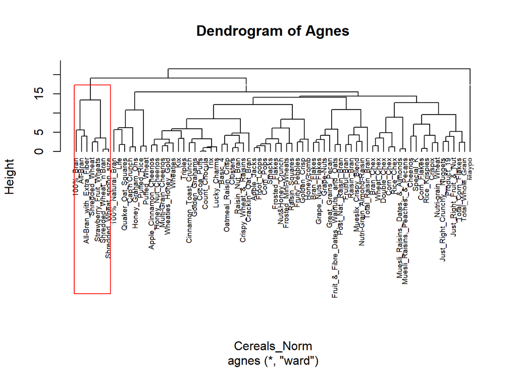

```r
pltree(hc_ward, cex = 0.6, hang = -1, main = "Dendrogram of Agnes")
rect.hclust(as.hclust(hc_ward), k = 3, border = c("red","white","white"))
```

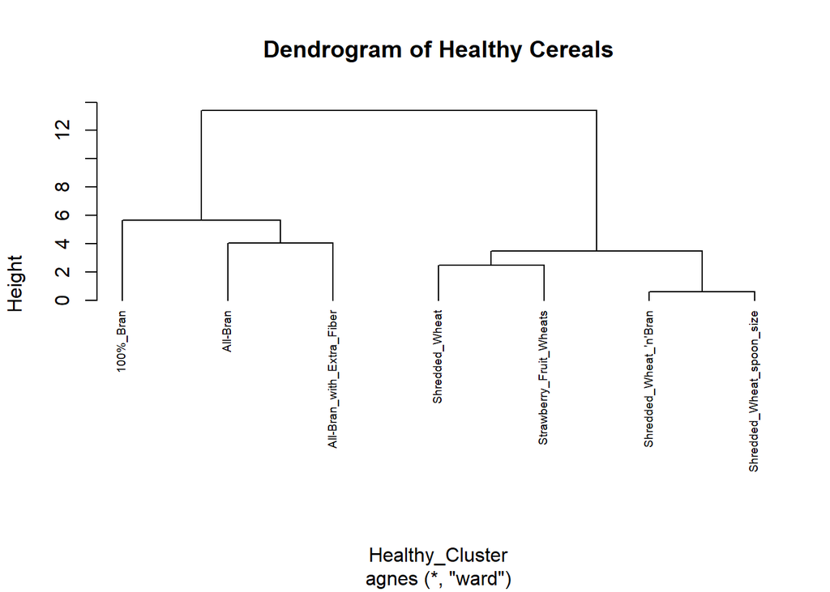

```r
Healthy_Cluster <- Cereals_Norm[Clusters_Ward == 1, ]
HC_Healthy_Cluster <- agnes(Healthy_Cluster, method = "ward")
pltree(HC_Healthy_Cluster, cex = 0.6, hang = -1, main = "Dendrogram of Healthy Cereals")
```

```r
row.names(Healthy_Cluster)
```

```
## [1] "100%_Bran"                 "All-Bran"
## [3] "All-Bran_with_Extra_Fiber" "Shredded_Wheat"
## [5] "Shredded_Wheat_'n'Bran"    "Shredded_Wheat_spoon_size"
## [7] "Strawberry_Fruit_Wheats"
```

The first cluster from the original clustering is perfect for the set of cereals requested by the elementary public schools. This cluster of cereals is very healthy and there are enough for there to be a different cereal a day (Monday - Friday).

The data should be normalized because features with larger magnitudes (like calories, potass, and sodium) will influence the model more than the other features.

If the data is not normalized you are forced to only use features with similar scales or manually use your own weights to fix the scales.